# Anàlisi de la cohort de BLCA utilitzant informació de MCN

## Preparació de les dades per a l’anàlisi

El fitxer de dades amb informació de l’estat WGD (Bielski) conté 251 casos de la cohort de BLCA.

Tenim 433 fitxers de recomptes de la cohort de BLCA.

L’anàlisi inclourà 250 mostres, 108 mostres sense WGD i 142 mostres amb WGD. Un 57% de les mostres de l’anàlisi han patit WGD.

La mida de les llibreries varia entre 4.215029810^{7} i 1.49300210^{8} i la mida mitjana és de 8.158187410^{7}.

## Pre-processament de les dades

Per a la filtració s’ha utilitzat un llindar de CPM de 0.13 i s’han filtrat 39196 gens, és a dir un 65% dels gens que teníem inicialment.

El rang de valors dels factors de normalització és de 0.4412165, 1.576758.

## Exploració de les dades

### Gràfics de densitat

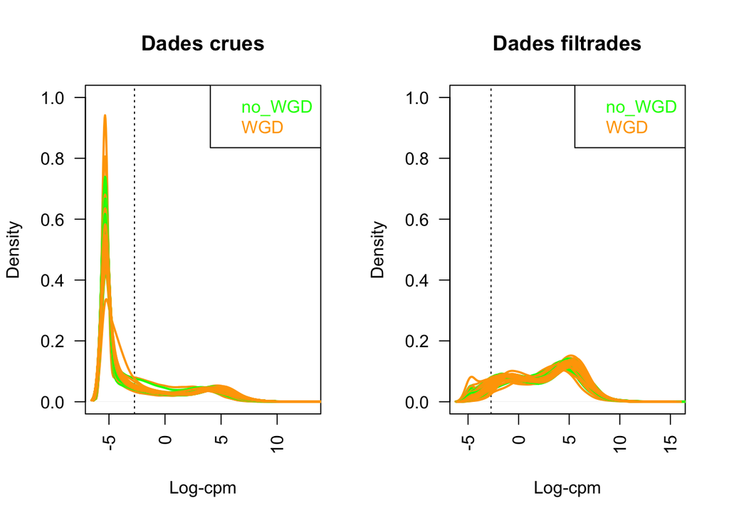

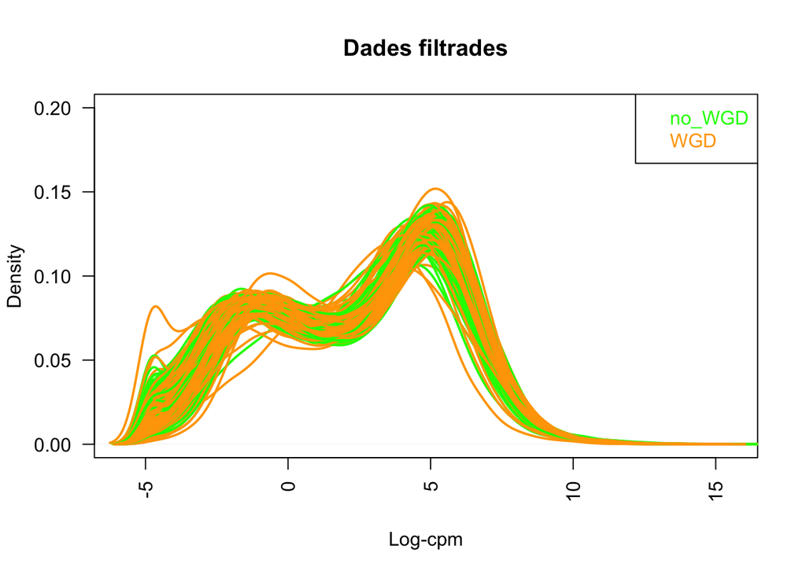

### Gràfic d’escalat multidimensional

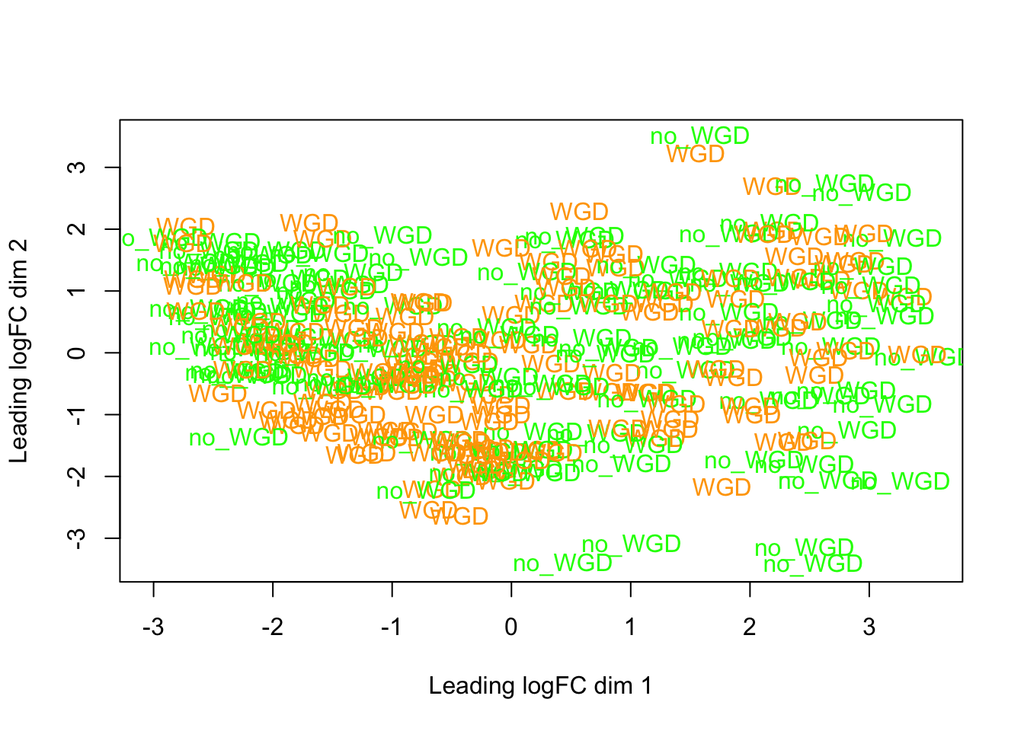

### Heatmap del gens més variables

Matriu de distàncies dels logCPM dels gens més variables. En aquest cas extraiem els 500 gens més variables a partir de les dades filtrades i normalitzades.

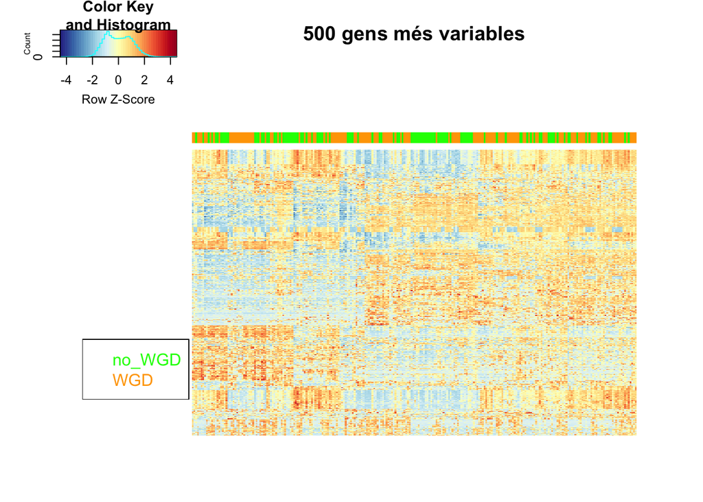

## Resultats de l’anàlisi d’expressió diferencial

### Nombre de gens diferencialment expressats

Contrastos amb p-valor ajustat (FDR) inferior a 0.05:

```
##        WGDvsNoWGD
## Down         1699
## NotSig      17360
## Up           2228
```

Contrastos amb p-valor sense ajustar inferior a 0.05 i valor absolut de log2-fold-change superior a 0.5 , aproximadament equivalent a un fold-change de 0.7 i 1.4:

```
##        WGDvsNoWGD
## Down          944
## NotSig      19073
## Up           1270
```

### Llista de gens ordenats per significació

```
##       ensembl_gene_id hgnc_symbol      logFC      P.Value    adj.P.Val
## 5598  ENSG00000129810        SGO1  1.0211920 1.779737e-14 3.788527e-10
## 7526  ENSG00000143228        NUF2  1.0885555 7.188966e-13 5.850486e-09
## 17343 ENSG00000236947        <NA>  1.6945979 8.245154e-13 5.850486e-09
## 1255  ENSG00000076382       SPAG5  0.8158260 5.248998e-12 2.793386e-08
## 14396 ENSG00000197472      ZNF695  1.0791887 6.580469e-12 2.801569e-08
## 2249  ENSG00000101003       GINS1  0.7963895 1.030861e-11 3.512934e-08
## 12033 ENSG00000175063       UBE2C  0.9306357 1.155190e-11 3.512934e-08
## 7957  ENSG00000146410       MTFR2  0.7948868 1.375802e-11 3.660837e-08
## 2048  ENSG00000100167     SEPTIN3  1.9274793 2.415515e-11 5.141907e-08
## 5538  ENSG00000129195      PIMREG  1.0450556 2.393286e-11 5.141907e-08
## 4     ENSG00000000460    C1orf112  0.8132864 3.884804e-11 5.906845e-08
## 1065  ENSG00000070950       RAD18  0.6158142 3.499282e-11 5.906845e-08
## 9174  ENSG00000158850     B4GALT3  0.6094081 3.663954e-11 5.906845e-08
## 9912  ENSG00000163808       KIF15  0.9134558 3.529809e-11 5.906845e-08
## 643   ENSG00000051341        POLQ  0.8639668 6.736916e-11 9.351136e-08
## 8784  ENSG00000154920        EME1  0.8479569 7.465359e-11 9.351136e-08
## 20864 ENSG00000278023        RDM1  1.1998897 7.467906e-11 9.351136e-08
## 6442  ENSG00000135709    KIAA0513 -0.8699472 8.852563e-11 1.046914e-07
## 15720 ENSG00000215784      FAM72D  0.9711884 1.194306e-10 1.338063e-07
## 1647  ENSG00000088325        TPX2  0.9636225 1.507054e-10 1.604033e-07
```

### Representació gràfica dels resultats

#### Gràfic mitjana-diferència

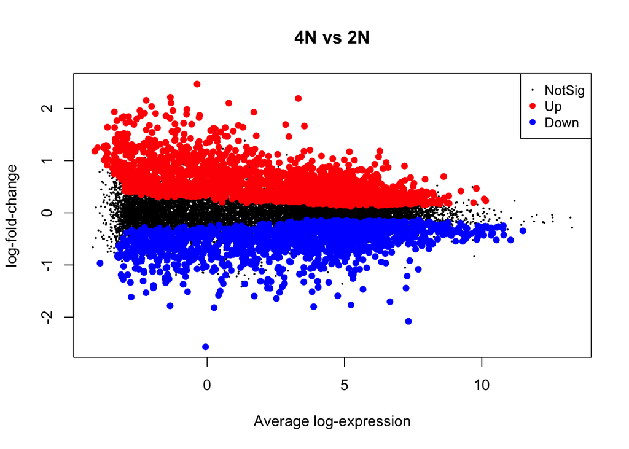

#### Gràfic de volcà

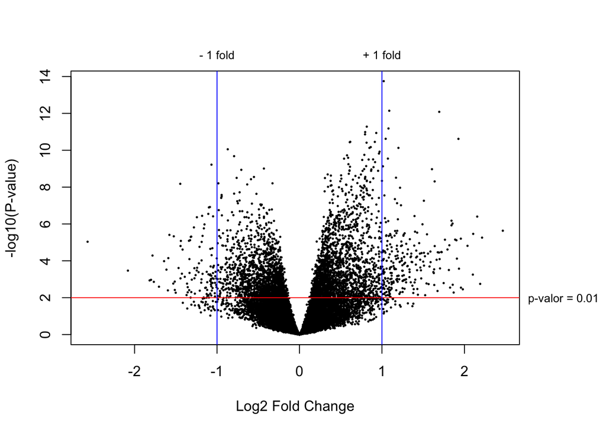

#### Heatmap dels gens més significatius

100 gens amb p-valor ajustat més baix:

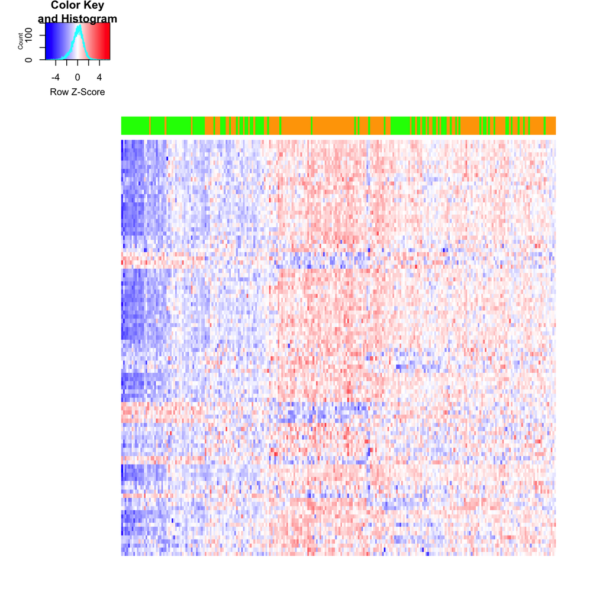

100 gens amb p-valor ajustat més baix després d’haver filtrat per aquells gens amb un logFC en valor absolut superior a 0.5 (aproximadament equivalent a FC superior a 1.4 o inferior a 0.7):

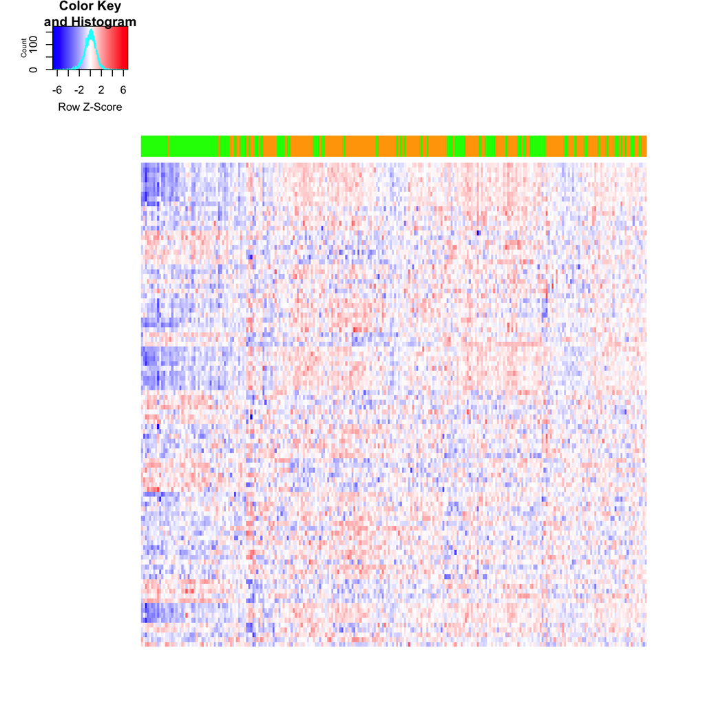

## Resultats de l’anàlisi d’enriquiment amb permutació de gene sets

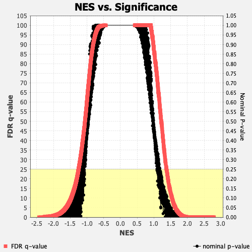

Termes enriquits al grup WGD

| NAME | FDR.q.val | NES |
| --- | --- | --- |
| GO_NUCLEAR_CHROMOSOME_SEGREGATION | 0 | 2.794891 |
| GO_CHROMOSOME_SEGREGATION | 0 | 2.775622 |
| GO_DNA_PACKAGING | 0 | 2.759411 |
| GO_DNA_CONFORMATION_CHANGE | 0 | 2.743265 |
| GO_DNA_DEPENDENT_DNA_REPLICATION | 0 | 2.740606 |
| GO_CHROMATIN_ASSEMBLY | 0 | 2.736409 |
| GO_SISTER_CHROMATID_SEGREGATION | 0 | 2.730912 |
| GO_MITOTIC_SISTER_CHROMATID_SEGREGATION | 0 | 2.730557 |
| GO_MEIOTIC_CELL_CYCLE_PROCESS | 0 | 2.727400 |
| GO_CHROMATIN_ASSEMBLY_OR_DISASSEMBLY | 0 | 2.689613 |
| GO_CENTROMERE_COMPLEX_ASSEMBLY | 0 | 2.688885 |
| GO_NUCLEOSOME_ORGANIZATION | 0 | 2.681537 |
| GO_CHROMATIN_REMODELING_AT_CENTROMERE | 0 | 2.668496 |
| GO_DNA_REPLICATION_INDEPENDENT_NUCLEOSOME_ORGANIZATION | 0 | 2.651760 |
| GO_CELL_CYCLE_DNA_REPLICATION | 0 | 2.638367 |
| GO_HISTONE_EXCHANGE | 0 | 2.631583 |
| GO_MEIOTIC_CELL_CYCLE | 0 | 2.628942 |
| GO_MITOTIC_NUCLEAR_DIVISION | 0 | 2.617696 |
| GO_MEIOTIC_CHROMOSOME_SEGREGATION | 0 | 2.605921 |
| GO_ORGANELLE_FISSION | 0 | 2.585746 |

Termes enriquits al grup no_WGD

| NAME | FDR.q.val | NES |
| --- | --- | --- |
| GO_INTERFERON_GAMMA_MEDIATED_SIGNALING_PATHWAY | 0.0000000 | -2.432282 |
| GO_T_CELL_SELECTION | 0.0000000 | -2.390587 |
| GO_RESPONSE_TO_INTERFERON_GAMMA | 0.0000000 | -2.370635 |
| GO_MESENCHYME_MORPHOGENESIS | 0.0013203 | -2.305932 |
| GO_RESPONSE_TO_TYPE_I_INTERFERON | 0.0014060 | -2.286097 |
| GO_POSITIVE_T_CELL_SELECTION | 0.0014698 | -2.279883 |
| GO_NEGATIVE_REGULATION_OF_VIRAL_LIFE_CYCLE | 0.0030307 | -2.268380 |
| GO_POSITIVE_REGULATION_OF_INTERLEUKIN_8_SECRETION | 0.0030848 | -2.250095 |
| GO_INTERLEUKIN_1_BETA_PRODUCTION | 0.0031283 | -2.243120 |
| GO_ALPHA_BETA_T_CELL_ACTIVATION | 0.0028154 | -2.242143 |
| GO_TUMOR_NECROSIS_FACTOR_SUPERFAMILY_CYTOKINE_PRODUCTION | 0.0027165 | -2.232550 |
| GO_ADAPTIVE_IMMUNE_RESPONSE | 0.0026369 | -2.229049 |
| GO_RESPONSE_TO_INTERFERON_BETA | 0.0025719 | -2.214561 |
| GO_CHEMOKINE_PRODUCTION | 0.0045201 | -2.174174 |
| GO_CELLULAR_RESPONSE_TO_MECHANICAL_STIMULUS | 0.0042188 | -2.171771 |
| GO_I_KAPPAB_KINASE_NF_KAPPAB_SIGNALING | 0.0041795 | -2.168320 |
| GO_POSITIVE_REGULATION_OF_I_KAPPAB_KINASE_NF_KAPPAB_SIGNALING | 0.0040388 | -2.165888 |
| GO_POSITIVE_REGULATION_OF_DEFENSE_RESPONSE_TO_VIRUS_BY_HOST | 0.0040137 | -2.153939 |
| GO_B_CELL_RECEPTOR_SIGNALING_PATHWAY | 0.0038970 | -2.152602 |
| GO_CELL_CHEMOTAXIS | 0.0039682 | -2.139159 |

## Anàlisis d’immunitat

### ESTIMATE

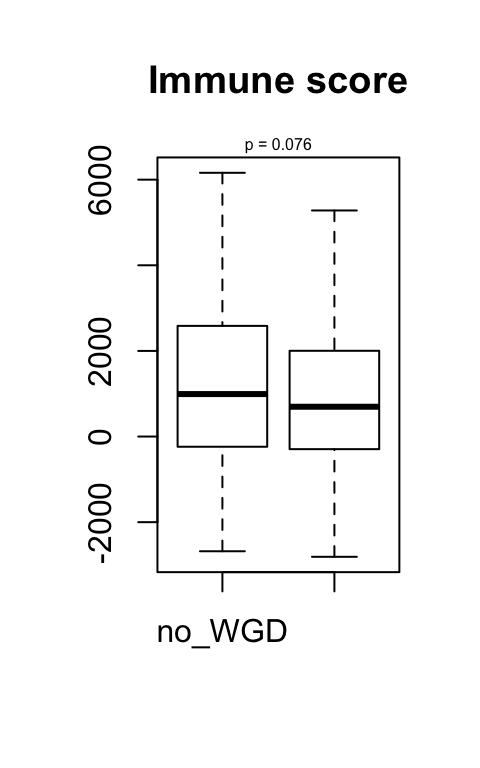

### Immunophenoscore

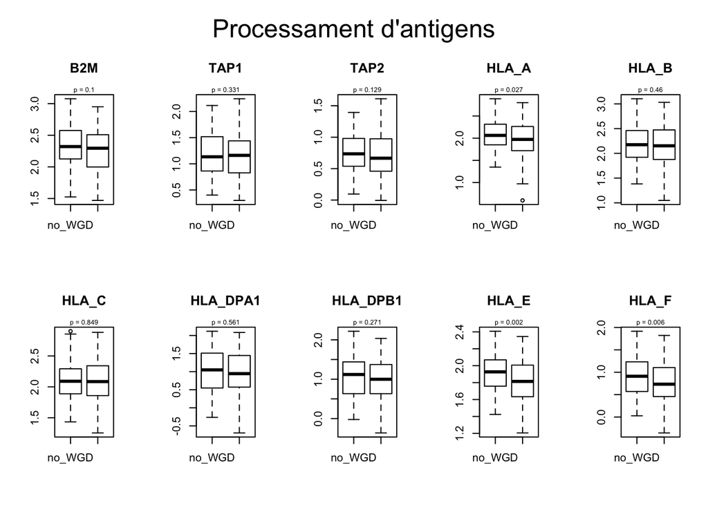

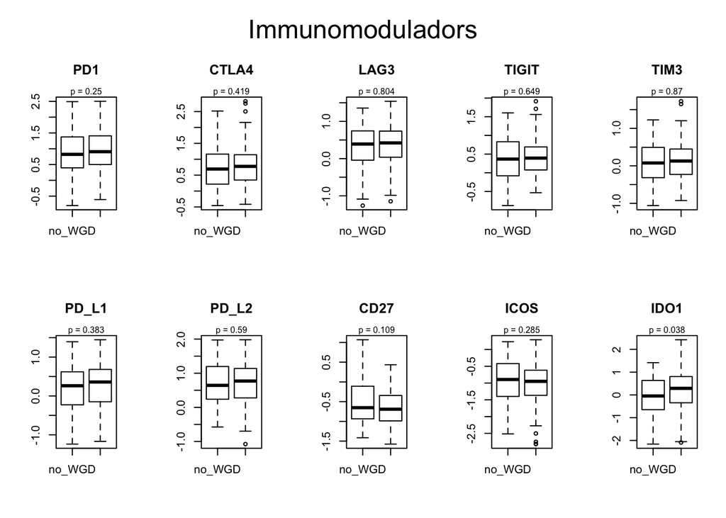

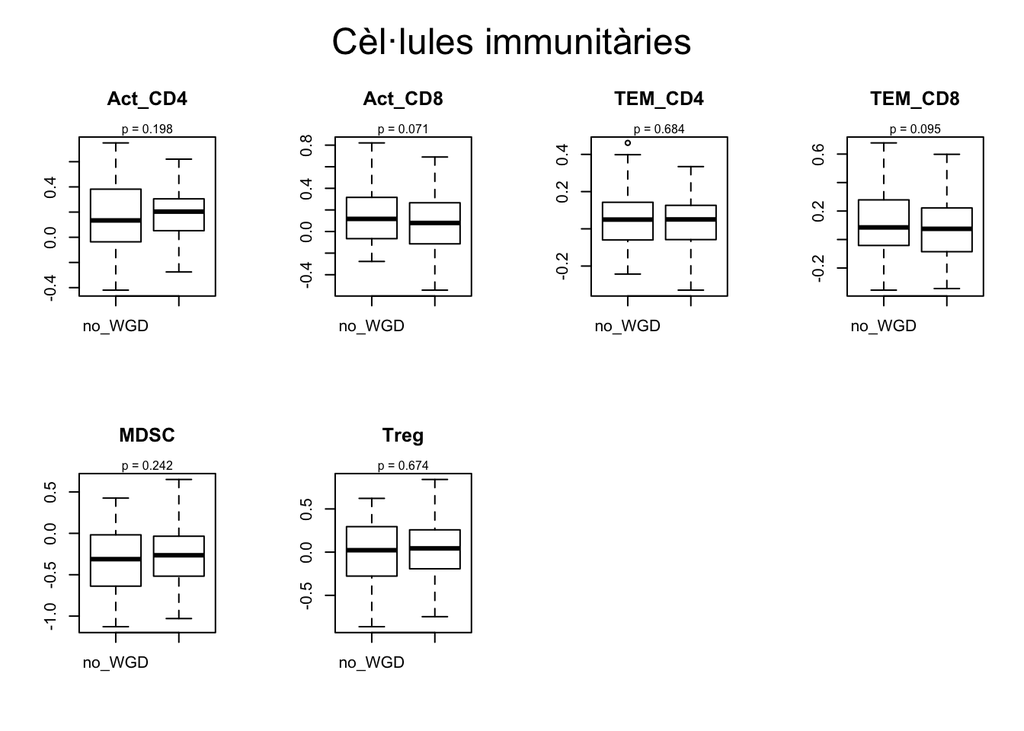

### Signatura 12-Chemokines

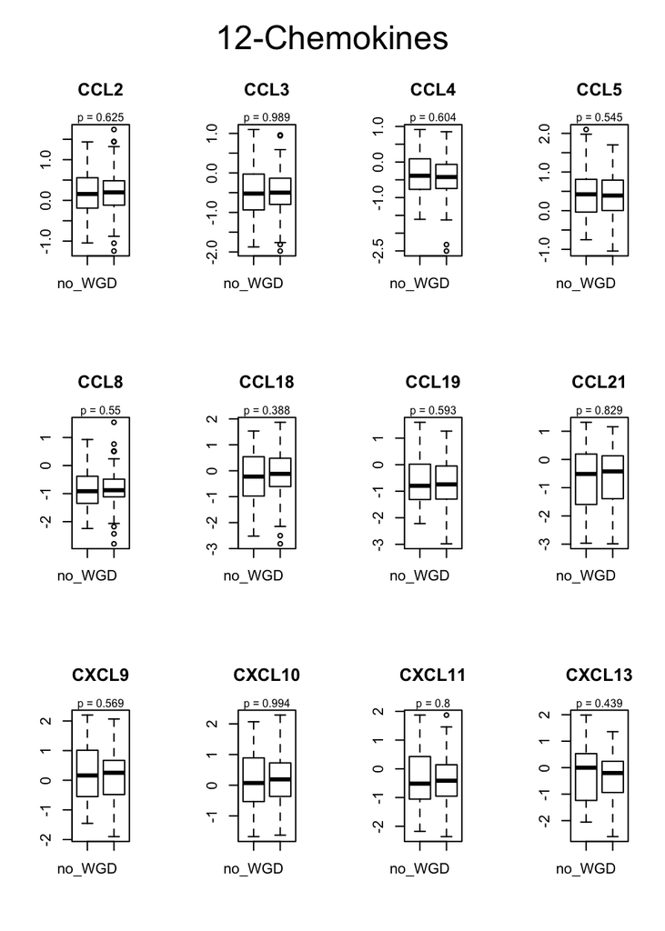